# Análisis evolución Covid-19 Chile casos y decesos (13/04/2020)

Claudio Bustos

13/4/2020

- Reportes anteriores: https://github.com/clbustos/analisis_covid19_chile

## Análisis de series de casos

La serie de casos se hace hace partir de los 25 casos, excepto para Atacama y Aysén, donde se inicia del quinto caso, para facilitar la comparación desde un punto de un punto de partida común. Si analizamos con detención la serie total, para los últimos 14 días se puede ver una progresiva desaceleración de la serie total. Esta se puede argumentar está causada por las desaceleraciones de las series en regiones, ya que la serie Metropolitana aparece con una tasa mayor en los últimos 4 días que en el resto de la serie.

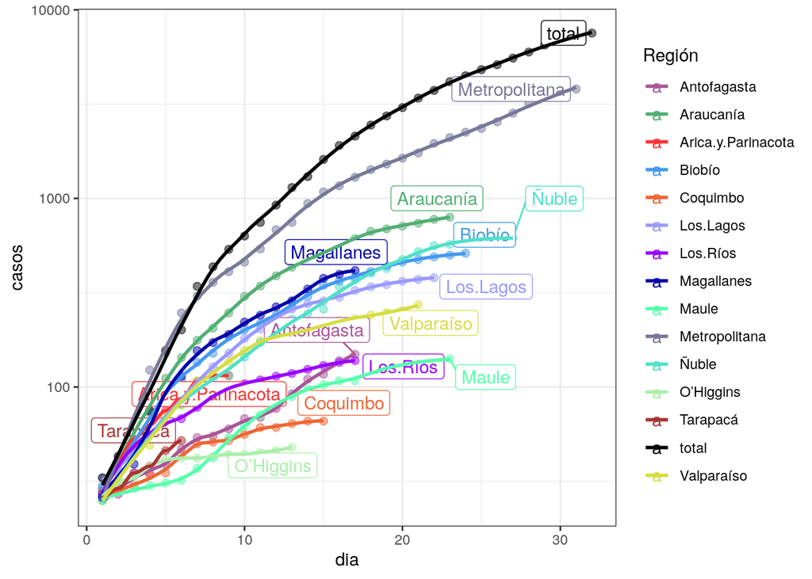

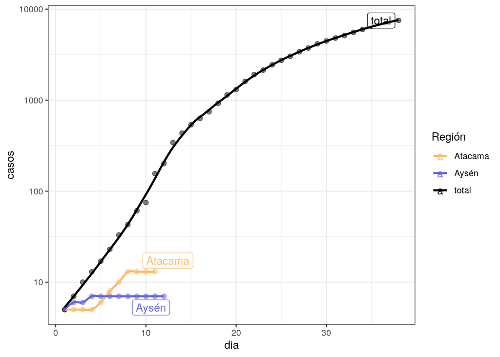

La serie por región se hace partir de los 5 primeros casos.

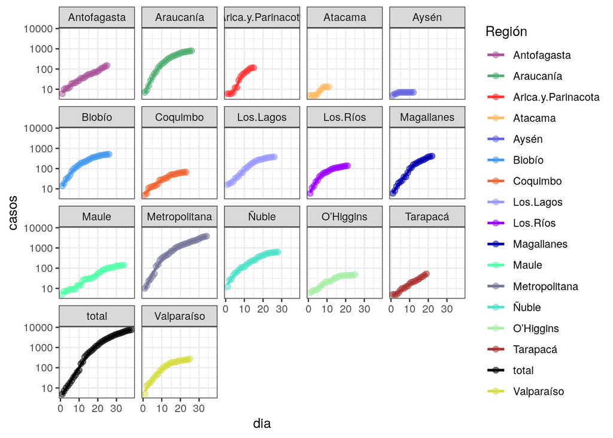

Podemos ver que en varias series nos estamos acercando a la deseada tasa 1 de casos en el tiempo *t* vs casos en tiempo *t-1*. En particular, Aysén hace varios días no presenta casos nuevos.

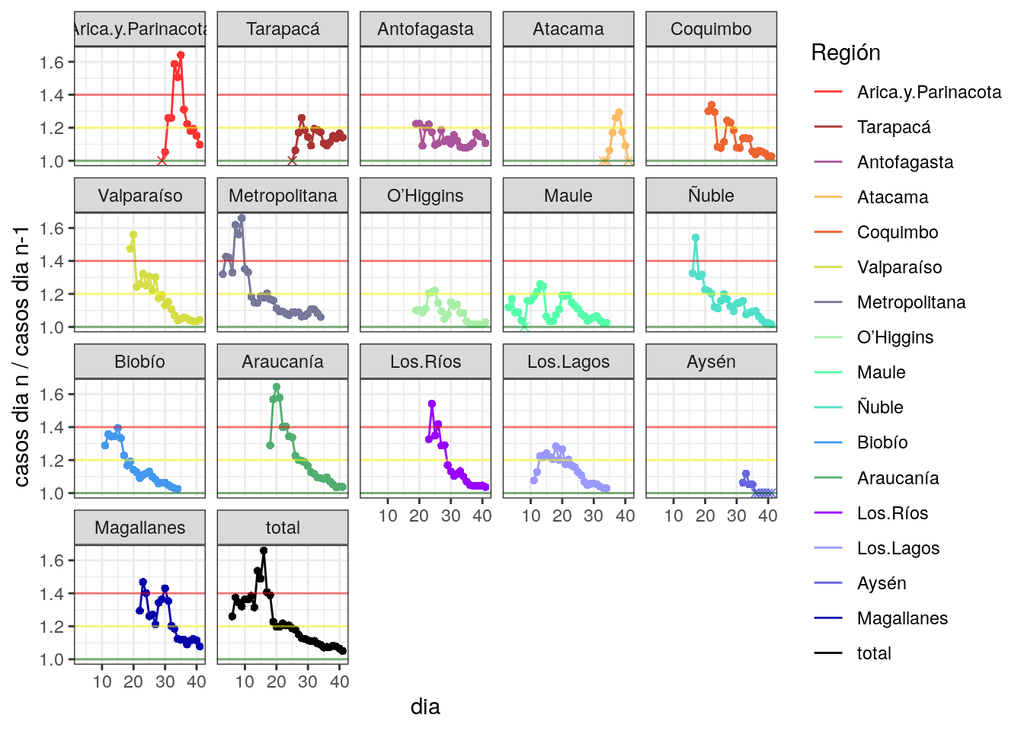

Para algunas series, es ya posible visualizar el descenso en la tasa de casos nuevos. Para ello, ocuparemos una ventana de 5 días para calcular la tasa móvil. Acá se puede ver con mayor claridad como la Metropolitana ha estado más tiempo aumentando la cantidad de casos nuevos por días, tendencia que se traspasa a la serie total.

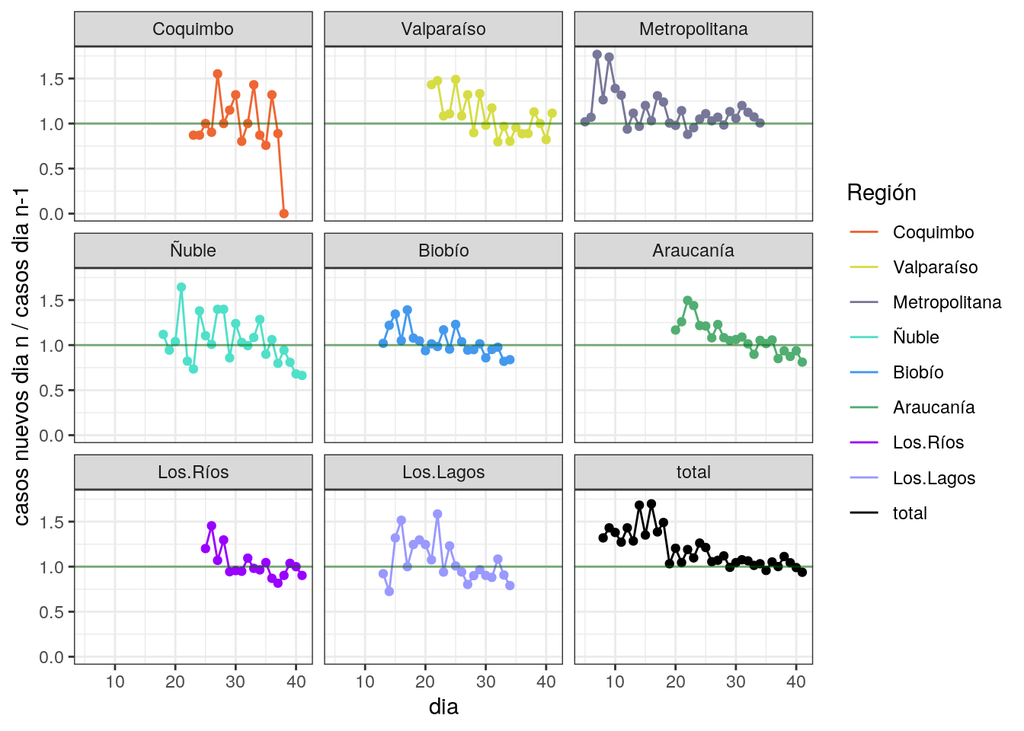

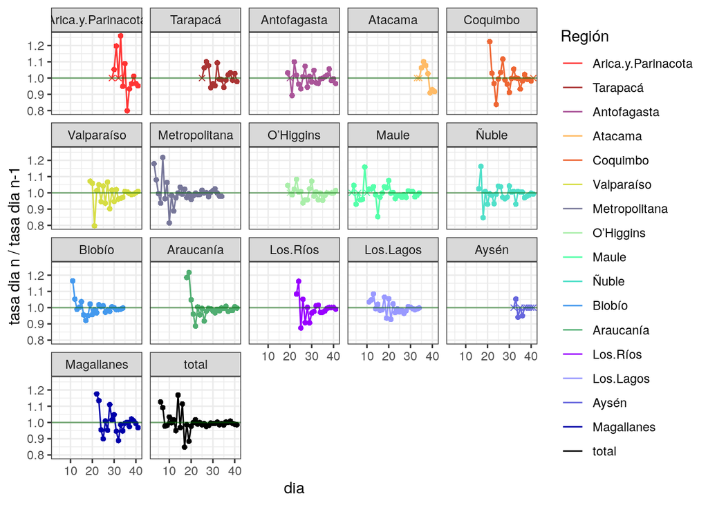

## Predicción

### Predicción para serie total

Recordemos que la regresión exponencial se eliminó, porque ya no calza con la serie total. A partir del análisis del resultado del algoritmo de la última semana, para la predicción total se recorta la serie a partir de lo 50 casos.

|  | casos | li | ls |
| --- | --- | --- | --- |
| **Observado** | 7525 | NA | NA |
| **ARIMA(1,1,0)** | 13392.66 | 5673.2 | 31615.9 |
| **T+AR(1)** | 6873.746 | 6211.361 | 8209.918 |
| **T+AR(4)** | 6950.628 | 6297.919 | 8204.888 |

Hoy los resultados de AR(1) y AR(4) se parecen más que otros días.

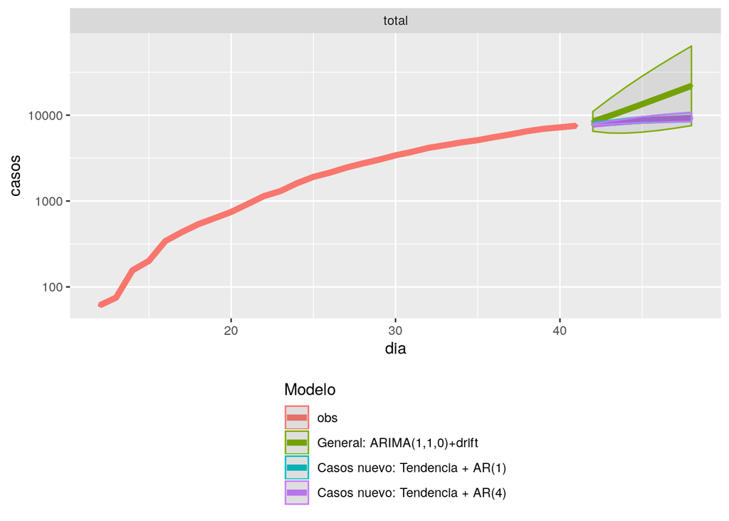

Casos nuevos: tendencia + AR(4) : total

|  | dia | casos | li | ls |
| --- | --- | --- | --- | --- |
| **31** | 42 | 7760 | 7670 | 7907 |
| **32** | 43 | 8103 | 7870 | 8494 |
| **33** | 44 | 8375 | 8023 | 8977 |
| **34** | 45 | 8685 | 8174 | 9611 |
| **35** | 46 | 8896 | 8276 | 10050 |
| **36** | 47 | 9094 | 8370 | 10466 |
| **37** | 48 | 9250 | 8441 | 10809 |

Casos nuevos: tendencia + AR(1) : total

|  | dia | casos | li | ls |
| --- | --- | --- | --- | --- |
| **31** | 42 | 7837 | 7699 | 8085 |
| **32** | 43 | 8118 | 7846 | 8622 |
| **33** | 44 | 8380 | 7981 | 9131 |
| **34** | 45 | 8617 | 8102 | 9592 |
| **35** | 46 | 8831 | 8212 | 10009 |
| **36** | 47 | 9021 | 8310 | 10380 |
| **37** | 48 | 9190 | 8396 | 10709 |

ARIMA(1,1,0) con deriva : total

|  | dia | casos | li | ls |
| --- | --- | --- | --- | --- |
| **31** | 42 | 8450 | 6479 | 11021 |
| **32** | 43 | 9769 | 6191 | 15417 |
| **33** | 44 | 11426 | 6177 | 21137 |
| **34** | 45 | 13425 | 6342 | 28422 |
| **35** | 46 | 15803 | 6638 | 37622 |
| **36** | 47 | 18615 | 7044 | 49195 |
| **37** | 48 | 21933 | 7550 | 63722 |

### Predicciones para serie total usando predicción por regiones.

Otro modelo posible de análisis es usar la suma de las predicciones parciales por región. No he calculado los intervalos de confianza, porque para que sean adecuados debería considerar la covarianza entre las series de las distintas regiones.

El modelo de sumas de T+AR(1) en 7 días predice 10102, 852 casos más que los que predicen los otros modelos.

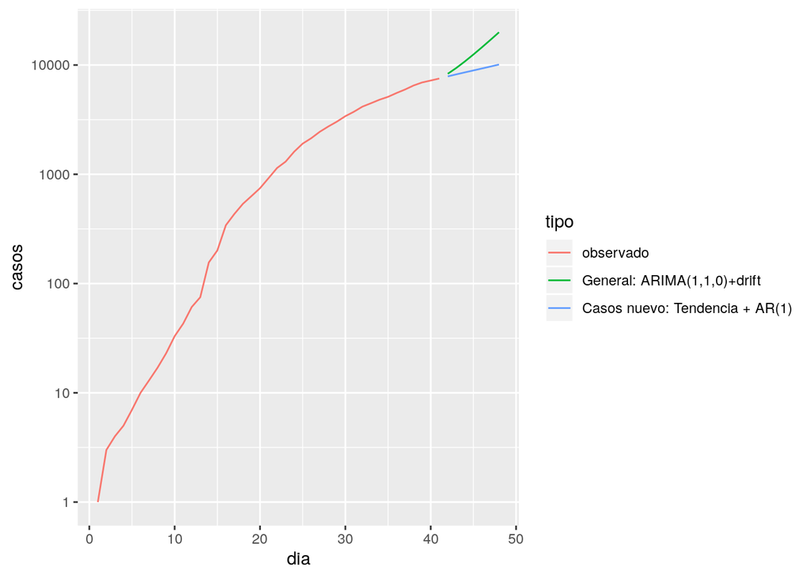

| dia | tipo | casos |
| --- | --- | --- |
| 1 | observado | 1 |
| 2 | observado | 3 |
| 3 | observado | 4 |
| 4 | observado | 5 |
| 5 | observado | 7 |
| 6 | observado | 10 |
| 7 | observado | 13 |
| 8 | observado | 17 |
| 9 | observado | 23 |
| 10 | observado | 33 |
| 11 | observado | 43 |
| 12 | observado | 61 |
| 13 | observado | 75 |
| 14 | observado | 156 |
| 15 | observado | 201 |
| 16 | observado | 342 |
| 17 | observado | 434 |
| 18 | observado | 537 |
| 19 | observado | 632 |
| 20 | observado | 746 |
| 21 | observado | 922 |
| 22 | observado | 1142 |
| 23 | observado | 1306 |
| 24 | observado | 1610 |
| 25 | observado | 1909 |
| 26 | observado | 2139 |
| 27 | observado | 2449 |
| 28 | observado | 2738 |
| 29 | observado | 3031 |
| 30 | observado | 3404 |
| 31 | observado | 3737 |
| 32 | observado | 4161 |
| 33 | observado | 4471 |
| 34 | observado | 4815 |
| 35 | observado | 5116 |
| 36 | observado | 5546 |
| 37 | observado | 5972 |
| 38 | observado | 6501 |
| 39 | observado | 6927 |
| 40 | observado | 7213 |
| 41 | observado | 7525 |
| 42 | General: ARIMA(1,1,0)+drift | 8316 |
| 43 | General: ARIMA(1,1,0)+drift | 9405 |
| 44 | General: ARIMA(1,1,0)+drift | 10785 |
| 45 | General: ARIMA(1,1,0)+drift | 12479 |
| 46 | General: ARIMA(1,1,0)+drift | 14529 |
| 47 | General: ARIMA(1,1,0)+drift | 16990 |
| 48 | General: ARIMA(1,1,0)+drift | 19933 |
| 42 | Casos nuevo: Tendencia + AR(1) | 7871 |
| 43 | Casos nuevo: Tendencia + AR(1) | 8214 |
| 44 | Casos nuevo: Tendencia + AR(1) | 8564 |
| 45 | Casos nuevo: Tendencia + AR(1) | 8922 |
| 46 | Casos nuevo: Tendencia + AR(1) | 9295 |
| 47 | Casos nuevo: Tendencia + AR(1) | 9685 |
| 48 | Casos nuevo: Tendencia + AR(1) | 10102 |

### Predicción por regiones

Recordemos que el algoritmo inicia desde 3 casos en cada Región .

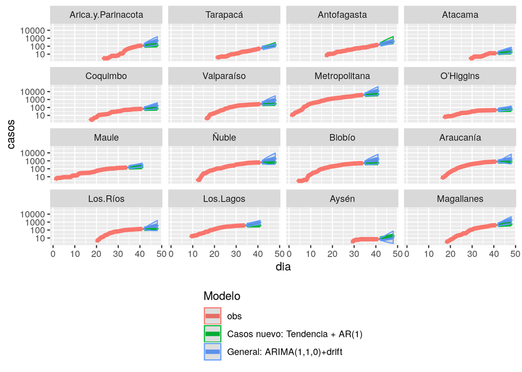

Las tablas por regiones se incluye en el Anexo I

## Decesos

Si observamos la serie de decesos, tanto la serie como total como para la Región Metropolitana sigue un patrón exponencial, con tasas del 20.4% y 16.7% diario, respectivamente. La tasa de la Región Metropolitana se mantiene constante desde ayer.

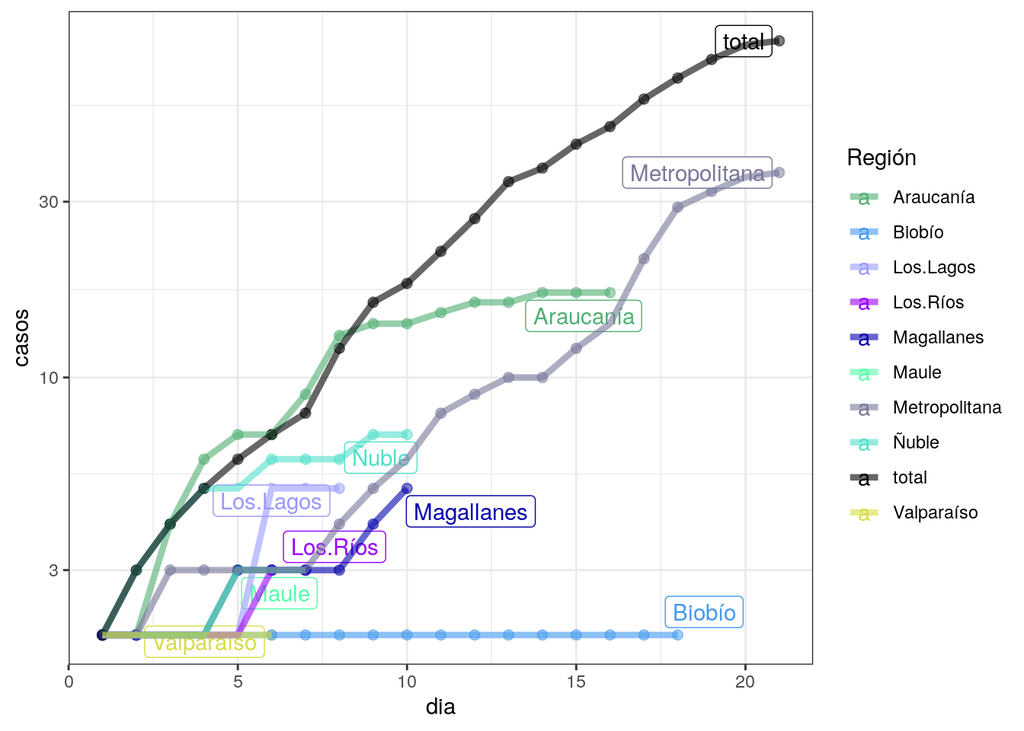

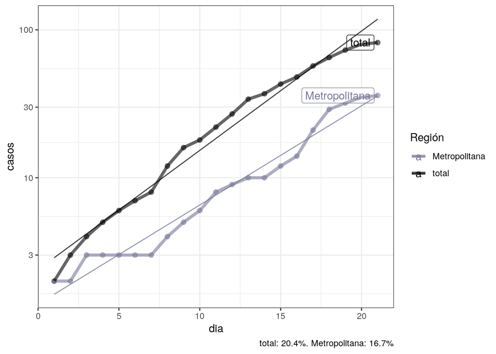

**Fuentes de información**: Principalmente, se utilizó el reporte diario del [MINSAL](https://www.minsal.cl/nuevo-coronavirus-2019-ncov/casos-confirmados-en-chile-covid-19/), usando [Wayback machine](https://archive.org/web/) para recopilar la información ya no disponible.

## Anexo I: Predicciones por región

Casos nuevos: tendencia + AR(1) : Arica.y.Parinacota

|  | dia | casos | li | ls |
| --- | --- | --- | --- | --- |
| **20** | 42 | 118.2 | 115.5 | 135.7 |
| **21** | 43 | 121.7 | 116 | 158.2 |
| **22** | 44 | 124.5 | 116.5 | 176.9 |
| **23** | 45 | 126.7 | 116.8 | 191.3 |
| **24** | 46 | 128.3 | 117 | 202 |
| **25** | 47 | 129.4 | 117.2 | 209.6 |
| **26** | 48 | 130.2 | 117.3 | 214.9 |

Casos nuevos: tendencia + AR(1) : Tarapacá

|  | dia | casos | li | ls |
| --- | --- | --- | --- | --- |
| **22** | 42 | 59.67 | 55.43 | 69.12 |
| **23** | 43 | 68.69 | 59.35 | 89.89 |
| **24** | 44 | 79.66 | 64.1 | 115.2 |
| **25** | 45 | 93.01 | 69.89 | 146 |
| **26** | 46 | 109.4 | 76.99 | 183.9 |
| **27** | 47 | 129.7 | 85.79 | 230.8 |
| **28** | 48 | 155.1 | 96.78 | 289.3 |

Casos nuevos: tendencia + AR(1) : Antofagasta

|  | dia | casos | li | ls |
| --- | --- | --- | --- | --- |
| **26** | 42 | 170.2 | 153.3 | 253.9 |
| **27** | 43 | 192.9 | 157.6 | 373.4 |
| **28** | 44 | 221.9 | 163.1 | 526.2 |
| **29** | 45 | 257.4 | 169.8 | 714 |
| **30** | 46 | 302 | 178.3 | 949.2 |
| **31** | 47 | 358 | 188.9 | 1245 |
| **32** | 48 | 429.2 | 202.4 | 1621 |

Casos nuevos: tendencia + AR(1) : Atacama

|  | dia | casos | li | ls |
| --- | --- | --- | --- | --- |
| **14** | 42 | 13.94 | 13.39 | 15.24 |
| **15** | 43 | 14.74 | 13.73 | 17.19 |
| **16** | 44 | 15.42 | 14.01 | 18.82 |
| **17** | 45 | 15.97 | 14.23 | 20.15 |
| **18** | 46 | 16.4 | 14.41 | 21.2 |
| **19** | 47 | 16.74 | 14.55 | 22.02 |
| **20** | 48 | 17 | 14.66 | 22.64 |

Casos nuevos: tendencia + AR(1) : Coquimbo

|  | dia | casos | li | ls |
| --- | --- | --- | --- | --- |
| **26** | 42 | 67.69 | 66.36 | 74.05 |
| **27** | 43 | 69.07 | 66.64 | 80.76 |
| **28** | 44 | 70.32 | 66.89 | 86.9 |
| **29** | 45 | 71.44 | 67.12 | 92.34 |
| **30** | 46 | 72.42 | 67.32 | 97.15 |
| **31** | 47 | 73.28 | 67.5 | 101.3 |
| **32** | 48 | 74.03 | 67.65 | 105 |

Casos nuevos: tendencia + AR(1) : Valparaíso

|  | dia | casos | li | ls |
| --- | --- | --- | --- | --- |
| **27** | 42 | 276.2 | 274 | 283 |
| **28** | 43 | 281.1 | 275.5 | 299.4 |
| **29** | 44 | 284.2 | 276.4 | 310.1 |
| **30** | 45 | 286.9 | 277.2 | 319.4 |
| **31** | 46 | 289 | 277.8 | 326.5 |
| **32** | 47 | 290.6 | 278.3 | 332 |
| **33** | 48 | 291.9 | 278.6 | 336.2 |

Casos nuevos: tendencia + AR(1) : Metropolitana

|  | dia | casos | li | ls |
| --- | --- | --- | --- | --- |
| **35** | 35 | 3967 | 3869 | 4213 |
| **36** | 36 | 4115 | 3927 | 4590 |
| **37** | 37 | 4252 | 3980 | 4937 |
| **38** | 38 | 4376 | 4029 | 5253 |
| **39** | 39 | 4488 | 4073 | 5540 |
| **40** | 40 | 4589 | 4113 | 5797 |
| **41** | 41 | 4679 | 4148 | 6026 |

Casos nuevos: tendencia + AR(1) : O’Higgins

|  | dia | casos | li | ls |
| --- | --- | --- | --- | --- |
| **26** | 42 | 48.78 | 48.25 | 50.43 |
| **27** | 43 | 49.43 | 48.46 | 52.44 |
| **28** | 44 | 49.97 | 48.64 | 54.12 |
| **29** | 45 | 50.42 | 48.78 | 55.51 |
| **30** | 46 | 50.79 | 48.9 | 56.65 |
| **31** | 47 | 51.09 | 49 | 57.58 |
| **32** | 48 | 51.33 | 49.07 | 58.32 |

Casos nuevos: tendencia + AR(1) : Maule

|  | dia | casos | li | ls |
| --- | --- | --- | --- | --- |
| **35** | 35 | 144.9 | 141.8 | 158.7 |
| **36** | 36 | 148.8 | 142.7 | 177.7 |
| **37** | 37 | 152.7 | 143.5 | 196.4 |
| **38** | 38 | 156.5 | 144.3 | 214.2 |
| **39** | 39 | 160 | 145 | 231.1 |
| **40** | 40 | 163.3 | 145.7 | 247.1 |
| **41** | 41 | 166.4 | 146.3 | 262.1 |

Casos nuevos: tendencia + AR(1) : Ñuble

|  | dia | casos | li | ls |
| --- | --- | --- | --- | --- |
| **31** | 42 | 626 | 619.8 | 653.9 |
| **32** | 43 | 632.1 | 621.1 | 681.9 |
| **33** | 44 | 637 | 622.2 | 704.1 |
| **34** | 45 | 640.8 | 623 | 721.2 |
| **35** | 46 | 643.7 | 623.7 | 734.3 |
| **36** | 47 | 645.9 | 624.2 | 744.1 |
| **37** | 48 | 647.5 | 624.5 | 751.3 |

Casos nuevos: tendencia + AR(1) : Biobío

|  | dia | casos | li | ls |
| --- | --- | --- | --- | --- |
| **32** | 35 | 519.2 | 514.9 | 529.9 |
| **33** | 36 | 524.8 | 517.1 | 544 |
| **34** | 37 | 529.1 | 518.8 | 554.6 |
| **35** | 38 | 532.2 | 520.1 | 562.5 |
| **36** | 39 | 534.5 | 521 | 568.3 |
| **37** | 40 | 536.2 | 521.7 | 572.4 |
| **38** | 41 | 537.3 | 522.1 | 575.2 |

Casos nuevos: tendencia + AR(1) : Araucanía

|  | dia | casos | li | ls |
| --- | --- | --- | --- | --- |
| **27** | 42 | 809.2 | 802.3 | 822.5 |
| **28** | 43 | 819.9 | 807.8 | 843.6 |
| **29** | 44 | 828 | 812 | 859.4 |
| **30** | 45 | 834 | 815 | 871 |
| **31** | 46 | 838.2 | 817.2 | 879.3 |
| **32** | 47 | 841.2 | 818.7 | 885.1 |
| **33** | 48 | 843.3 | 819.8 | 889.1 |

Casos nuevos: tendencia + AR(1) : Los.Ríos

|  | dia | casos | li | ls |
| --- | --- | --- | --- | --- |
| **23** | 42 | 140.7 | 139.2 | 143.9 |
| **24** | 43 | 142.9 | 140.2 | 148.7 |
| **25** | 44 | 144.6 | 141 | 152.5 |
| **26** | 45 | 146 | 141.6 | 155.5 |
| **27** | 46 | 147 | 142.1 | 157.8 |
| **28** | 47 | 147.8 | 142.5 | 159.5 |
| **29** | 48 | 148.4 | 142.8 | 160.8 |

Casos nuevos: tendencia + AR(1) : Los.Lagos

|  | dia | casos | li | ls |
| --- | --- | --- | --- | --- |
| **27** | 35 | 384.9 | 382 | 391.8 |
| **28** | 36 | 388.9 | 383.5 | 402.6 |
| **29** | 37 | 391.8 | 384.6 | 410.3 |
| **30** | 38 | 393.9 | 385.4 | 416 |
| **31** | 39 | 395.3 | 385.9 | 419.9 |
| **32** | 40 | 396.3 | 386.3 | 422.6 |
| **33** | 41 | 397 | 386.5 | 424.4 |

Casos nuevos: tendencia + AR(1) : Aysén

|  | dia | casos | li | ls |
| --- | --- | --- | --- | --- |
| **14** | 42 | 8.2 | 7.87 | 8.65 |
| **15** | 43 | 9.45 | 8.76 | 10.41 |
| **16** | 44 | 10.87 | 9.77 | 12.41 |
| **17** | 45 | 12.45 | 10.89 | 14.64 |
| **18** | 46 | 14.26 | 12.17 | 17.21 |
| **19** | 47 | 16.37 | 13.66 | 20.19 |
| **20** | 48 | 18.86 | 15.42 | 23.7 |

Casos nuevos: tendencia + AR(1) : Magallanes

|  | dia | casos | li | ls |
| --- | --- | --- | --- | --- |
| **25** | 42 | 440.5 | 421.6 | 513.2 |
| **26** | 43 | 461.9 | 427 | 599 |
| **27** | 44 | 481.6 | 431.9 | 678.3 |
| **28** | 45 | 499 | 436.2 | 748.2 |
| **29** | 46 | 514.1 | 439.9 | 809 |
| **30** | 47 | 527 | 443.1 | 861 |
| **31** | 48 | 537.9 | 445.8 | 904.5 |

ARIMA(1,1,0) con deriva : Arica.y.Parinacota

|  | dia | casos | li | ls |
| --- | --- | --- | --- | --- |
| **20** | 42 | 141.3 | 89.19 | 223.9 |
| **21** | 43 | 173.1 | 90.74 | 330.2 |
| **22** | 44 | 212 | 96.32 | 466.8 |
| **23** | 45 | 259.7 | 104.5 | 645.2 |
| **24** | 46 | 318.2 | 115.1 | 879.3 |
| **25** | 47 | 389.7 | 128.1 | 1186 |
| **26** | 48 | 477.4 | 143.5 | 1588 |

ARIMA(1,1,0) con deriva : Tarapacá

|  | dia | casos | li | ls |
| --- | --- | --- | --- | --- |
| **22** | 42 | 59.22 | 49.44 | 70.94 |
| **23** | 43 | 67.37 | 53.14 | 85.43 |
| **24** | 44 | 76.66 | 57.64 | 102 |
| **25** | 45 | 87.23 | 62.97 | 120.8 |
| **26** | 46 | 99.25 | 69.11 | 142.5 |
| **27** | 47 | 112.9 | 76.1 | 167.6 |
| **28** | 48 | 128.5 | 84 | 196.5 |

ARIMA(1,1,0) con deriva : Antofagasta

|  | dia | casos | li | ls |
| --- | --- | --- | --- | --- |
| **26** | 42 | 172.1 | 136.2 | 217.3 |
| **27** | 43 | 195.6 | 145.8 | 262.6 |
| **28** | 44 | 223.2 | 157.1 | 317.2 |
| **29** | 45 | 254.5 | 170.8 | 379.2 |
| **30** | 46 | 290.2 | 186.7 | 451.3 |
| **31** | 47 | 330.9 | 204.7 | 535 |
| **32** | 48 | 377.4 | 225.2 | 632.4 |

ARIMA(1,1,0) con deriva : Atacama

|  | dia | casos | li | ls |
| --- | --- | --- | --- | --- |
| **14** | 42 | 14.82 | 10.46 | 20.99 |
| **15** | 43 | 16.76 | 10.4 | 27 |
| **16** | 44 | 18.96 | 10.63 | 33.83 |
| **17** | 45 | 21.45 | 11.03 | 41.72 |
| **18** | 46 | 24.26 | 11.56 | 50.94 |
| **19** | 47 | 27.45 | 12.2 | 61.76 |
| **20** | 48 | 31.06 | 12.95 | 74.47 |

ARIMA(1,1,0) con deriva : Coquimbo

|  | dia | casos | li | ls |
| --- | --- | --- | --- | --- |
| **26** | 42 | 74.65 | 54.12 | 103 |
| **27** | 43 | 84.85 | 53.34 | 135 |
| **28** | 44 | 96.47 | 54.41 | 171 |
| **29** | 45 | 109.7 | 56.48 | 213 |
| **30** | 46 | 124.7 | 59.28 | 262.3 |
| **31** | 47 | 141.8 | 62.71 | 320.5 |
| **32** | 48 | 161.2 | 66.73 | 389.3 |

ARIMA(1,1,0) con deriva : Valparaíso

|  | dia | casos | li | ls |
| --- | --- | --- | --- | --- |
| **27** | 42 | 316.7 | 216.8 | 462.5 |
| **28** | 43 | 373.2 | 206 | 676.2 |
| **29** | 44 | 441.3 | 206.3 | 944.1 |
| **30** | 45 | 522.2 | 212.7 | 1282 |
| **31** | 46 | 618 | 223.3 | 1710 |
| **32** | 47 | 731.4 | 237.5 | 2253 |
| **33** | 48 | 865.6 | 254.9 | 2940 |

ARIMA(1,1,0) con deriva : Metropolitana

|  | dia | casos | li | ls |
| --- | --- | --- | --- | --- |
| **35** | 35 | 4323 | 3212 | 5818 |
| **36** | 36 | 5067 | 3026 | 8484 |
| **37** | 37 | 6015 | 2988 | 12109 |
| **38** | 38 | 7178 | 3046 | 16915 |
| **39** | 39 | 8586 | 3176 | 23208 |
| **40** | 40 | 10279 | 3366 | 31396 |
| **41** | 41 | 12312 | 3608 | 42006 |

ARIMA(1,1,0) con deriva : O’Higgins

|  | dia | casos | li | ls |
| --- | --- | --- | --- | --- |
| **26** | 42 | 51.44 | 44.58 | 59.36 |
| **27** | 43 | 55.72 | 43.54 | 71.32 |
| **28** | 44 | 60.63 | 43.44 | 84.62 |
| **29** | 45 | 66.08 | 43.98 | 99.29 |
| **30** | 46 | 72.07 | 44.98 | 115.5 |
| **31** | 47 | 78.62 | 46.35 | 133.4 |
| **32** | 48 | 85.79 | 48.02 | 153.3 |

ARIMA(1,1,0) con deriva : Maule

|  | dia | casos | li | ls |
| --- | --- | --- | --- | --- |
| **35** | 35 | 156.8 | 122.9 | 200.1 |
| **36** | 36 | 173.4 | 124.4 | 241.8 |
| **37** | 37 | 191.8 | 128.2 | 287 |
| **38** | 38 | 212.2 | 133.6 | 337.1 |
| **39** | 39 | 234.7 | 140.2 | 393.1 |
| **40** | 40 | 259.6 | 147.8 | 456.2 |
| **41** | 41 | 287.2 | 156.4 | 527.4 |

ARIMA(1,1,0) con deriva : Ñuble

|  | dia | casos | li | ls |
| --- | --- | --- | --- | --- |
| **31** | 42 | 698.1 | 442.3 | 1102 |
| **32** | 43 | 815.3 | 386.6 | 1719 |
| **33** | 44 | 961.5 | 362.1 | 2553 |
| **34** | 45 | 1137 | 353.6 | 3658 |
| **35** | 46 | 1346 | 354.6 | 5112 |
| **36** | 47 | 1594 | 362.1 | 7019 |
| **37** | 48 | 1888 | 374.7 | 9509 |

ARIMA(1,1,0) con deriva : Biobío

|  | dia | casos | li | ls |
| --- | --- | --- | --- | --- |
| **32** | 35 | 597.2 | 371.6 | 959.8 |
| **33** | 36 | 706.6 | 347.7 | 1436 |
| **34** | 37 | 837.4 | 344.9 | 2033 |
| **35** | 38 | 992.5 | 352.6 | 2794 |
| **36** | 39 | 1176 | 367.2 | 3769 |
| **37** | 40 | 1394 | 387.5 | 5018 |
| **38** | 41 | 1653 | 412.8 | 6618 |

ARIMA(1,1,0) con deriva : Araucanía

|  | dia | casos | li | ls |
| --- | --- | --- | --- | --- |
| **27** | 42 | 840 | 700.1 | 1008 |
| **28** | 43 | 908.9 | 624.2 | 1323 |
| **29** | 44 | 1002 | 559.2 | 1797 |
| **30** | 45 | 1123 | 506.4 | 2489 |
| **31** | 46 | 1273 | 464.8 | 3487 |
| **32** | 47 | 1458 | 432.6 | 4914 |
| **33** | 48 | 1683 | 408.2 | 6941 |

ARIMA(1,1,0) con deriva : Los.Ríos

|  | dia | casos | li | ls |
| --- | --- | --- | --- | --- |
| **23** | 42 | 149.5 | 115 | 194.3 |
| **24** | 43 | 167.8 | 101.8 | 276.7 |
| **25** | 44 | 192.7 | 93.2 | 398.4 |
| **26** | 45 | 224.3 | 88.01 | 571.7 |
| **27** | 46 | 263.4 | 85.33 | 813.1 |
| **28** | 47 | 310.9 | 84.52 | 1144 |
| **29** | 48 | 368.3 | 85.19 | 1592 |

ARIMA(1,1,0) con deriva : Los.Lagos

|  | dia | casos | li | ls |
| --- | --- | --- | --- | --- |
| **27** | 35 | 426.2 | 347.8 | 522.3 |
| **28** | 36 | 482.9 | 356.5 | 654.2 |
| **29** | 37 | 547.8 | 374.8 | 800.7 |
| **30** | 38 | 621.4 | 399.1 | 967.6 |
| **31** | 39 | 705 | 428.4 | 1160 |
| **32** | 40 | 799.8 | 462.4 | 1383 |
| **33** | 41 | 907.3 | 501.2 | 1642 |

ARIMA(1,1,0) con deriva : Aysén

|  | dia | casos | li | ls |
| --- | --- | --- | --- | --- |
| **14** | 42 | 7.25 | 5.53 | 9.51 |
| **15** | 43 | 7.7 | 4.49 | 13.23 |
| **16** | 44 | 8.33 | 3.69 | 18.82 |
| **17** | 45 | 9.14 | 3.1 | 26.95 |
| **18** | 46 | 10.12 | 2.66 | 38.51 |
| **19** | 47 | 11.28 | 2.33 | 54.64 |
| **20** | 48 | 12.63 | 2.08 | 76.84 |

ARIMA(1,1,0) con deriva : Magallanes

|  | dia | casos | li | ls |
| --- | --- | --- | --- | --- |
| **25** | 42 | 493.9 | 365.3 | 667.9 |
| **26** | 43 | 605.7 | 375 | 978.2 |
| **27** | 44 | 747.9 | 403.4 | 1387 |
| **28** | 45 | 925.1 | 445 | 1923 |
| **29** | 46 | 1145 | 498.6 | 2628 |
| **30** | 47 | 1417 | 564.7 | 3554 |
| **31** | 48 | 1753 | 644.5 | 4768 |